# Character displacement of bill ratio in penguins

Lucas Eckert<sup>1*</sup>

1. Department of Biology, McGill University, Montreal, QC, Canada

*Corresponding Author

Email: lucas.eckert@mail.mcgill.ca

# Abstract

- Character displacement is a classic result of interspecific competition
- Existing data from three species of penguins provide an opportunity to explore this phenomenon
- We explore the possibility of character displacement in bill morphology
- We define bill ratio to be the ratio between bill depth and length, and to be an informative trait to look for specialization
- We find that the three species of penguins differ significantly in bill ratio, providing another example of character displacement
- This reinforces the importance of interspecific competition in trait evolution

# Introduction

Character displacement is an evolutionary divergence in traits due to competition (Grant & Grant 2006). This phenomenon has been observed across taxa (Schluter 1994). Here, we explore another potential case of character displacement of a trophic trait in three species of penguins.

Bill morphology is an important trophic trait (Grant 1985). While bill depth could be analyzed alone, we argue that if bill depth is correlated with bill length, the ratio of depth to length should be more informative.

Penguins eat fish and other small marine prey, but bill morphology affects specific diet (Chávez-Hoffmeister 2020). The Adelie, Chinstrap, and Gentoo penguins all inhabit the Palmer Archipelago (Gorman *et al.* 2014). We explore potential character displacement between these species in bill morphology, specifically bill ratio.

# Methods

Data on bill morphology for each of the species was collected from the palmerpenguins R package (Horst *et al.* 2020). The bill ratio was defined as follows:

$$BillRatio = BillDepth \div BillLength$$

We first explored the potential positive relationship between bill depth and length, which if present, punctuates the need to calculate bill ratio. We then test for differences in mean bill ratio among the species using pairwise T-tests with a Bonferonni correction.

We used R version 4.2.2 (R Core Team 2022) and the following R packages: GGally v. 2.1.2 (Schloerke *et al.* 2021), palmerpenguins v. 0.1.1 (Horst *et al.* 2020), rmarkdown v. 2.18 (Xie *et al.* 2018, 2020; Allaire *et al.* 2022), tidyverse v. 1.3.2 (Wickham *et al.* 2019).

# Results

As expected, there is a positive relationship between bill length and depth in all three species of penguins (Figure 1).

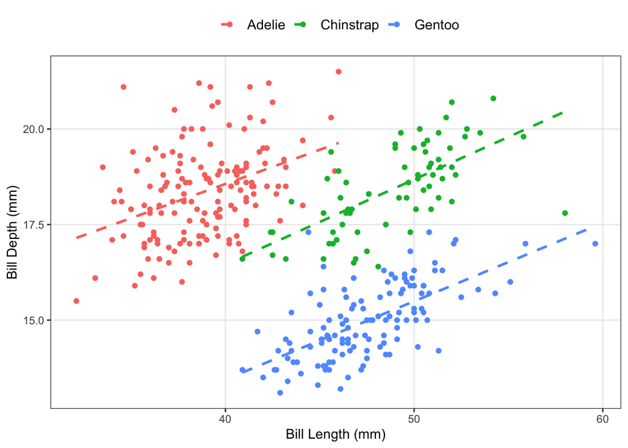

The species also differ in mean bill ratio (Figure 2). Adelie penguins have the greatest bill ratio (mean = 0.474), followed by Chinstrap (mean = 0.378), then Gentoo (mean = 0.316). Significant differences were confirmed among all three species using pairwise T-tests.

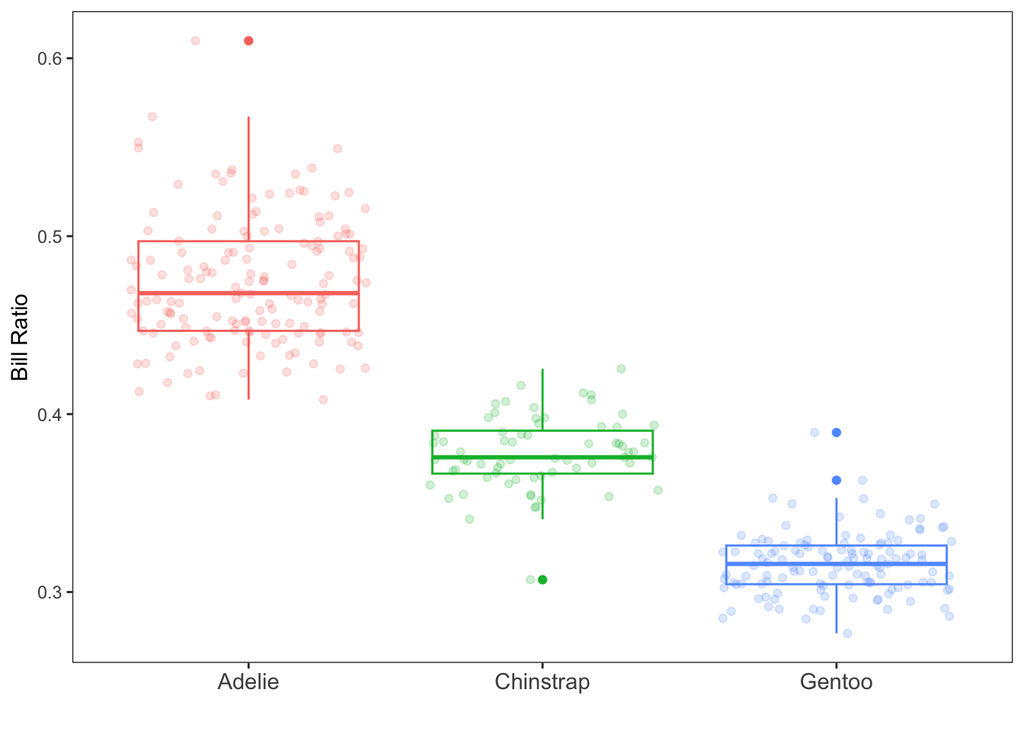

# Discussion

The three species differed in mean bill ratio. This suggests that there is character displacement in this trait, caused by competition for prey. This reinforces the importance of interspecific competition in trait evolution.

# References

Allaire, J., Xie, Y., McPherson, J., Luraschi, J., Ushey, K., Atkins, A., *et al.* (2022). *[rmarkdown: Dynamic documents for r](https://github.com/rstudio/rmarkdown)*.

Chávez-Hoffmeister, M. (2020). [Bill disparity and feeding strategies among fossil and modern penguins](https://doi.org/10.1017/pab.2020.10). *Paleobiology*, 46, 176–192.

Gorman, K.B., Williams, T.D. & Fraser, W.R. (2014). [Ecological Sexual Dimorphism and Environmental Variability within a Community of Antarctic Penguins (Genus Pygoscelis)](https://doi.org/10.1371/journal.pone.0090081). *PLOS ONE*, 9, e90081.

Grant, B.R. (1985). [SELECTION ON BILL CHARACTERS IN a POPULATION OF DARWIN’s FINCHES: GEOSPIZA CONIROSTRIS ON ISLA GENOVESA, GALÁPAGOS](https://doi.org/10.1111/j.1558-5646.1985.tb00392.x). *Evolution*, 39, 523–532.

Grant, P.R. & Grant, B.R. (2006). [Evolution of character displacement in darwin’s finches](https://doi.org/10.1126/science.1128374). *Science*, 313, 224–226.

Horst, A.M., Hill, A.P. & Gorman, K.B. (2020). *[palmerpenguins: Palmer archipelago (antarctica) penguin data](https://doi.org/10.5281/zenodo.3960218)*.

R Core Team. (2022). *[R: A language and environment for statistical computing](https://www.R-project.org/)*. R Foundation for Statistical Computing, Vienna, Austria.

Schloerke, B., Cook, D., Larmarange, J., Briatte, F., Marbach, M., Thoen, E., *et al.* (2021). *[GGally: Extension to “ggplot2”](https://CRAN.R-project.org/package=GGally)*.

Schluter, D. (1994). [Experimental evidence that competition promotes divergence in adaptive radiation](https://doi.org/10.1126/science.266.5186.798). *Science*, 266, 798–801.

Wickham, H., Averick, M., Bryan, J., Chang, W., McGowan, L.D., François, R., *et al.* (2019). [Welcome to the tidyverse](https://doi.org/10.21105/joss.01686). *Journal of Open Source Software*, 4, 1686.

Xie, Y., Allaire, J.J. & Grolemund, G. (2018). *[R markdown: The definitive guide](https://bookdown.org/yihui/rmarkdown)*. Chapman; Hall/CRC, Boca Raton, Florida.

Xie, Y., Dervieux, C. & Riederer, E. (2020). *[R markdown cookbook](https://bookdown.org/yihui/rmarkdown-cookbook)*. Chapman; Hall/CRC, Boca Raton, Florida.